# Purtell_ProblemSet03

Author

Colin Purtell

## STATS 506 Problem Set 2:

Link to repository: https://github.com/cspurtell/stat506

### Problem 1

```r
library(haven)
library(dplyr)
```

#### a.

```r
aux <- read_xpt("data/AUX_I.xpt")
demo <- read_xpt("data/DEMO_I.xpt")

# intersect(names(aux), names(demo))

merged <- inner_join(aux, demo, by = "SEQN")
dim(merged)
```

```
[1] 4582  119
```

The merged dataset has 4582 rows and 119 columns

#### b.

For the gender variable:

```r
merged <- merged %>%
  mutate(RIAGENDR = case_when(
    RIAGENDR == 1 ~ "Male",
    RIAGENDR == 2 ~ "Female",
    TRUE ~ NA_character_
  )) %>%
  mutate(RIAGENDR = factor(RIAGENDR))
```

For the citizenship status variable:

```r
merged <- merged %>%
  mutate(DMDCITZN = case_when(
    DMDCITZN == 1 ~ "Citizen by birth or naturalization",
    DMDCITZN == 2 ~ "Not a citizen",
    DMDCITZN == 7 ~ "Refused",
    DMDCITZN == 9 ~ "Don't Know",
    TRUE ~ NA_character_
  )) %>%
  mutate(DMDCITZN = factor(DMDCITZN))
```

For the number of children variable:

```r
merged <- merged %>%
  mutate(
    DMDHHSZA = as.numeric(DMDHHSZA),
    DMDHHSZA = ifelse(DMDHHSZA == 3, 3, DMDHHSZA)
  )
```

For the annual household income variable:

```r
merged <- merged %>%
  mutate(INDHHIN2 = case_when(
    INDHHIN2 == 1  ~ "$0–$4,999",
    INDHHIN2 == 2  ~ "$5,000–$9,999",
    INDHHIN2 == 3  ~ "$10,000–$14,999",
    INDHHIN2 == 4  ~ "$15,000–$19,999",
    INDHHIN2 == 5  ~ "$20,000–$24,999",
    INDHHIN2 == 6  ~ "$25,000–$34,999",
    INDHHIN2 == 7  ~ "$35,000–$44,999",
    INDHHIN2 == 8  ~ "$45,000–$54,999",
    INDHHIN2 == 9  ~ "$55,000–$64,999",
    INDHHIN2 == 10 ~ "$65,000–$74,999",
    INDHHIN2 == 14 ~ "$75,000–$99,999",
    INDHHIN2 == 15 ~ "≥$100,000",
    INDHHIN2 == 12 ~ "$20,000 and over",
    INDHHIN2 == 13 ~ "Under $20,000",
    INDHHIN2 == 77 ~ "Refused",
    INDHHIN2 == 99 ~ "Don't know",
    TRUE ~ NA_character_
  )) %>%
  mutate(
    INDHHIN2 = factor(
      INDHHIN2,
      levels = c(
        "$0–$4,999", "$5,000–$9,999", "$10,000–$14,999", "$15,000–$19,999",
        "$20,000–$24,999", "$25,000–$34,999", "$35,000–$44,999",
        "$45,000–$54,999", "$55,000–$64,999", "$65,000–$74,999",
        "$75,000–$99,999", "≥$100,000",
        "$20,000 and over", "Under $20,000",
        "Refused", "Don't know"
      )
    )
  )
```

#### c.

Need to convert annual household income to a continuous variable first:

```r
income_midpoints <- c(
  `1` = 2500, `2` = 7500, `3` = 12500, `4` = 17500,
  `5` = 22500, `6` = 30000, `7` = 40000, `8` = 50000,
  `9` = 60000, `10` = 70000, `14` = 87500, `15` = 110000,
  `12` = 60000, `13` = 15000, `77` = NA, `99` = NA
)

merged <- merged %>%
  mutate(
    INDHHIN2 = as.numeric(INDHHIN2),
    Income_cont = income_midpoints[as.character(INDHHIN2)]
  )
```

```r
library(broom)
library(pscl)
library(knitr)

model_1R <- glm(AUXTWIDR ~ RIAGENDR, data = merged, family = poisson)
model_2R <- glm(AUXTWIDR ~ RIAGENDR + DMDCITZN + DMDHHSZA + INDHHIN2,
                data = merged, family = poisson)

model_1L <- glm(AUXTWIDL ~ RIAGENDR, data = merged, family = poisson)
model_2L <- glm(AUXTWIDL ~ RIAGENDR + DMDCITZN + DMDHHSZA + INDHHIN2,
                data = merged, family = poisson)
```

```r
summarize_poisson <- function(model) {
  irr <- exp(coef(model))  # incidence rate ratios
  ci <- exp(confint(model))

  tidy_df <- broom::tidy(model) %>%
    mutate(
      IRR = exp(estimate),
      CI_low = exp(estimate - 1.96 * std.error),
      CI_high = exp(estimate + 1.96 * std.error)
    ) %>%
    select(term, IRR, CI_low, CI_high, p.value)

  stats <- data.frame(
    N = nobs(model),
    Pseudo_R2 = round(pscl::pR2(model)["McFadden"], 3),
    AIC = AIC(model)
  )

  list(coefs = tidy_df, stats = stats)
}

m1R <- summarize_poisson(model_1R)
```

```
fitting null model for pseudo-r2
```

```r
m2R <- summarize_poisson(model_2R)
```

```
fitting null model for pseudo-r2
```

```r
m1L <- summarize_poisson(model_1L)
```

```
fitting null model for pseudo-r2
```

```r
m2L <- summarize_poisson(model_2L)
```

```
fitting null model for pseudo-r2
```

The coefficient table is as follows:

```r
coefs_table <- bind_rows(
  m1R$coefs %>% mutate(Model = "1R: Right ear (Gender only)"),
  m2R$coefs %>% mutate(Model = "2R: Right ear (Full model)"),
  m1L$coefs %>% mutate(Model = "1L: Left ear (Gender only)"),
  m2L$coefs %>% mutate(Model = "2L: Left ear (Full model)")
) %>%
  select(Model, term, IRR, CI_low, CI_high, p.value) %>%
  mutate(across(c(IRR, CI_low, CI_high, p.value), ~round(., 3)))

kable(coefs_table, caption = "Incidence Rate Ratios for Poisson Models")
```

Incidence Rate Ratios for Poisson Models

| Model | term | IRR | CI_low | CI_high | p.value |
| --- | --- | --- | --- | --- | --- |
| 1R: Right ear (Gender only) | (Intercept) | 85.102 | 84.718 | 85.488 | 0.000 |
| 1R: Right ear (Gender only) | RIAGENDRMale | 0.991 | 0.984 | 0.997 | 0.006 |
| 2R: Right ear (Full model) | (Intercept) | 87.029 | 86.208 | 87.857 | 0.000 |
| 2R: Right ear (Full model) | RIAGENDRMale | 0.989 | 0.982 | 0.996 | 0.001 |
| 2R: Right ear (Full model) | DMDCITZNDon’t Know | 1.361 | 1.242 | 1.491 | 0.000 |
| 2R: Right ear (Full model) | DMDCITZNNot a citizen | 1.072 | 1.063 | 1.081 | 0.000 |
| 2R: Right ear (Full model) | DMDCITZNRefused | 1.600 | 1.483 | 1.725 | 0.000 |
| 2R: Right ear (Full model) | DMDHHSZA | 1.000 | 0.995 | 1.005 | 0.864 |
| 2R: Right ear (Full model) | INDHHIN2 | 0.996 | 0.995 | 0.997 | 0.000 |
| 1L: Left ear (Gender only) | (Intercept) | 85.863 | 85.475 | 86.254 | 0.000 |
| 1L: Left ear (Gender only) | RIAGENDRMale | 0.987 | 0.981 | 0.994 | 0.000 |
| 2L: Left ear (Full model) | (Intercept) | 88.428 | 87.594 | 89.270 | 0.000 |
| 2L: Left ear (Full model) | RIAGENDRMale | 0.988 | 0.981 | 0.995 | 0.000 |
| 2L: Left ear (Full model) | DMDCITZNDon’t Know | 1.134 | 1.027 | 1.253 | 0.013 |
| 2L: Left ear (Full model) | DMDCITZNNot a citizen | 1.046 | 1.037 | 1.055 | 0.000 |
| 2L: Left ear (Full model) | DMDCITZNRefused | 1.517 | 1.391 | 1.654 | 0.000 |
| 2L: Left ear (Full model) | DMDHHSZA | 0.984 | 0.979 | 0.989 | 0.000 |
| 2L: Left ear (Full model) | INDHHIN2 | 0.996 | 0.995 | 0.997 | 0.000 |

The model statistics table is as follows:

```r
stats_table <- bind_rows(
  m1R$stats %>% mutate(Model = "1R: Right ear (Gender only)"),
  m2R$stats %>% mutate(Model = "2R: Right ear (Full model)"),
  m1L$stats %>% mutate(Model = "1L: Left ear (Gender only)"),
  m2L$stats %>% mutate(Model = "2L: Left ear (Full model)")
) %>%
  select(Model, N, Pseudo_R2, AIC)

kable(stats_table, caption = "Model Sample Sizes, Pseudo-R², and AIC Values")
```

Model Sample Sizes, Pseudo-R², and AIC Values

|  | Model | N | Pseudo_R2 | AIC |
| --- | --- | --- | --- | --- |
| McFadden…1 | 1R: Right ear (Gender only) | 4149 | 0.000 | 96618.48 |
| McFadden…2 | 2R: Right ear (Full model) | 4022 | 0.006 | 92845.55 |
| McFadden…3 | 1L: Left ear (Gender only) | 4103 | 0.000 | 98685.15 |
| McFadden…4 | 2L: Left ear (Full model) | 3984 | 0.003 | 95637.14 |

#### d.

```r
summary(model_2L)
```

```
Call:
glm(formula = AUXTWIDL ~ RIAGENDR + DMDCITZN + DMDHHSZA + INDHHIN2,
    family = poisson, data = merged)

Coefficients:
                       Estimate Std. Error z value Pr(>|z|)
(Intercept)            4.482189   0.004835 926.957  < 2e-16 ***
RIAGENDRMale          -0.012060   0.003447  -3.498 0.000468 ***
DMDCITZNDon't Know     0.125940   0.050899   2.474 0.013350 *
DMDCITZNNot a citizen  0.044895   0.004335  10.356  < 2e-16 ***
DMDCITZNRefused        0.416699   0.044175   9.433  < 2e-16 ***
DMDHHSZA              -0.015824   0.002589  -6.111 9.88e-10 ***
INDHHIN2              -0.004027   0.000485  -8.302  < 2e-16 ***
---
Signif. codes:  0 '***' 0.001 '**' 0.01 '*' 0.05 '.' 0.1 ' ' 1

(Dispersion parameter for poisson family taken to be 1)

    Null deviance: 71272  on 3983  degrees of freedom
Residual deviance: 70970  on 3977  degrees of freedom
  (598 observations deleted due to missingness)
AIC: 95637

Number of Fisher Scoring iterations: 4
```

In Model 2L, there is a small but statistically significant gender difference in tympanometric width of the left ear (IRR = 0.988, p < 0.001). This suggests that, holding citizenship, number of young children, and income constant, males have on average slightly lower tympanometric width than females.

```r
exp(coef(model_2L))   # IRRs
```

```
          (Intercept)          RIAGENDRMale    DMDCITZNDon't Know
           88.4280307             0.9880122             1.1342144
DMDCITZNNot a citizen       DMDCITZNRefused              DMDHHSZA
            1.0459181             1.5169453             0.9843009
             INDHHIN2
            0.9959814
```

Specifically, we find that males have a 1.2% lower expected rate of the outcome, holding all else constant. This is because the IRR is less than 1.

### Problem 2

```r
library(DBI)
library(RSQLite)
library(microbenchmark)
con <- dbConnect(RSQLite::SQLite(), "data/sakila_master.db")
# dbListTables(con)
```

#### a.

Using R operations:

```r
customer_df <- dbGetQuery(con, "SELECT customer_id, store_id, active FROM customer") %>%
  mutate(active = as.numeric(active))
store_df <- dbGetQuery(con, "SELECT store_id, address_id FROM store")
store_stats <- customer_df %>%
  group_by(store_id) %>%
  summarise(
    total_customers = n(),
    active_customers = sum(active),
    pct_active = round(100 * active_customers / total_customers, 2)
  )
store_stats
```

```
# A tibble: 2 × 4
  store_id total_customers active_customers pct_active
     <int>           <int>            <dbl>      <dbl>
1        1             326              318       97.6
2        2             273              266       97.4
```

Using a single SQL query:

```r
query <- "
SELECT
  store_id,
  COUNT(customer_id) AS total_customers,
  SUM(active) AS active_customers,
  ROUND(100.0 * SUM(active)/COUNT(customer_id), 2) AS pct_active
FROM customer
GROUP BY store_id
"

store_stats_sql <- dbGetQuery(con, query)
store_stats_sql
```

```
  store_id total_customers active_customers pct_active
1        1             326              318      97.55
2        2             273              266      97.44
```

Testing performance of the above methods:

```r
microbenchmark(
  R_approach = {
    customer_df %>%
      group_by(store_id) %>%
      summarise(total_customers = n(),
                active_customers = sum(active),
                pct_active = round(100 * active_customers / n(), 2))
  },
  SQL_approach = dbGetQuery(con, query),
  times = 10
)
```

```
Unit: microseconds
         expr    min     lq    mean  median     uq    max neval
   R_approach 4810.9 4955.9 5358.02 5262.05 5581.6 6361.9    10
 SQL_approach  941.4 1052.8 1206.32 1103.05 1277.3 1645.4    10
```

#### b.

Using R operations:

```r
staff_df <- dbGetQuery(con, "SELECT staff_id, first_name, last_name, address_id FROM staff")
address_df <- dbGetQuery(con, "SELECT address_id, city_id FROM address")
city_df <- dbGetQuery(con, "SELECT city_id, country_id FROM city")
country_df <- dbGetQuery(con, "SELECT country_id, country FROM country")

staff_country <- staff_df %>%
  left_join(address_df, by = "address_id") %>%
  left_join(city_df, by = "city_id") %>%
  left_join(country_df, by = "country_id") %>%
  select(first_name, last_name, country)
staff_country
```

```
  first_name last_name   country
1       Mike   Hillyer    Canada
2        Jon  Stephens Australia
```

Using a single SQL query:

```r
query <- "
SELECT s.first_name, s.last_name, c.country
FROM staff s
JOIN address a ON s.address_id = a.address_id
JOIN city ci ON a.city_id = ci.city_id
JOIN country c ON ci.country_id = c.country_id
"

staff_country_sql <- dbGetQuery(con, query)
staff_country_sql
```

```
  first_name last_name   country
1       Mike   Hillyer    Canada
2        Jon  Stephens Australia
```

Testing performance of the above methods:

```r
microbenchmark(
  R_approach = {
    staff_df %>%
      left_join(address_df, by = "address_id") %>%
      left_join(city_df, by = "city_id") %>%
      left_join(country_df, by = "country_id") %>%
      select(first_name, last_name, country)
  },
  SQL_approach = dbGetQuery(con, query),
  times = 10
)
```

```
Unit: microseconds
         expr    min     lq    mean  median     uq     max neval
   R_approach 8444.0 8732.5 9611.70 9436.85 9696.5 12110.2    10
 SQL_approach  734.8  798.7  892.19  887.85 1025.5  1063.2    10
```

#### c.

Using R operations:

```r
payment_df <- dbGetQuery(con, "SELECT rental_id, amount FROM payment")
rental_df <- dbGetQuery(con, "SELECT rental_id, inventory_id FROM rental")
inventory_df <- dbGetQuery(con, "SELECT inventory_id, film_id FROM inventory")
film_df <- dbGetQuery(con, "SELECT film_id, title FROM film")

film_value <- payment_df %>%
  left_join(rental_df, by = "rental_id") %>%
  left_join(inventory_df, by = "inventory_id") %>%
  left_join(film_df, by = "film_id") %>%
  group_by(film_id, title) %>%
  summarise(total_value = sum(amount), .groups = 'drop')
film_value %>% filter(total_value == max(total_value))
```

```
# A tibble: 1 × 3
  film_id title            total_value
    <int> <chr>                  <dbl>
1     879 TELEGRAPH VOYAGE        232.
```

Using a single SQL query:

```r
query <- "
SELECT f.title, SUM(p.amount) AS total_value
FROM payment p
JOIN rental r ON p.rental_id = r.rental_id
JOIN inventory i ON r.inventory_id = i.inventory_id
JOIN film f ON i.film_id = f.film_id
GROUP BY f.film_id, f.title
HAVING SUM(p.amount) = (
    SELECT MAX(total_val) FROM (
        SELECT SUM(p2.amount) AS total_val
        FROM payment p2
        JOIN rental r2 ON p2.rental_id = r2.rental_id
        JOIN inventory i2 ON r2.inventory_id = i2.inventory_id
        GROUP BY i2.film_id
    )
)
"

film_max_sql <- dbGetQuery(con, query)
film_max_sql
```

```
             title total_value
1 TELEGRAPH VOYAGE      231.73
```

Testing the performance of the above methods:

```r
microbenchmark(
  R_approach = {
    film_value <- payment_df %>%
      left_join(rental_df, by = "rental_id") %>%
      left_join(inventory_df, by = "inventory_id") %>%
      left_join(film_df, by = "film_id") %>%
      group_by(film_id, title) %>%
      summarise(total_value = sum(amount), .groups='drop')
    film_value %>% filter(total_value == max(total_value))
  },
  SQL_approach = dbGetQuery(con, query),
  times = 10
)
```

```
Unit: milliseconds
         expr      min       lq      mean   median       uq      max neval
   R_approach  25.3268  27.3793  28.00991  28.0344  28.8685  30.9100    10
 SQL_approach 178.8834 182.7570 185.21517 184.9090 187.8152 192.8225    10
```

### Problem 3

```r
aus_data <- read.csv("data/au-500.csv")
```

#### a.

```r
library(stringr)
percent_com <- mean(str_detect(aus_data$web, "\\.com$")) * 100
percent_com
```

```
[1] 0
```

There does not appear to be any website URLS ending in .com, as they all seem to end in .com.aus

#### b.

```r
domains <- str_extract(aus_data$email, "(?<=@).*")
most_common_domain <- domains %>% table() %>% sort(decreasing = TRUE)
most_common_domain[1]
```

```
hotmail.com
        114
```

The most common domain name appears to be hotmail.com

#### c.

```r
non_alpha <- str_detect(aus_data$company_name, "[^A-Za-z ,]")
prop_non_alpha <- mean(non_alpha)
prop_non_alpha
```

```
[1] 0.09
```

Approximately 9% of company names contain non-alphabetic characters

```r
non_alpha2 <- str_detect(aus_data$company_name, "[^A-Za-z ,&]")
prop_non_alpha2 <- mean(non_alpha2)
prop_non_alpha2
```

```
[1] 0.008
```

#### d.

```r
convert_to_cell <- function(phone) {
  phone <- gsub("-", "", phone)
  ifelse(str_length(phone) == 10,
         paste0(substr(phone,1,4), "-", substr(phone,5,7), "-", substr(phone,8,10)),
         phone)
}

aus_data$phone1 <- sapply(aus_data$phone1, convert_to_cell)
aus_data$phone2 <- sapply(aus_data$phone2, convert_to_cell)
head(aus_data$phone1, 10)
```

```
 [1] "0381-749-123" "0799-973-366" "0855-589-019" "0260-444-682" "0214-556-085"
 [6] "0878-681-355" "0865-228-931" "0252-269-402" "0731-849-989" "0868-904-661"
```

```r
head(aus_data$phone2, 10)
```

```
 [1] "0458-665-290" "0497-622-620" "0427-885-282" "0443-795-912" "0453-666-885"
 [6] "0451-966-921" "0427-991-688" "0415-961-606" "0411-732-965" "0461-862-457"
```

#### e.

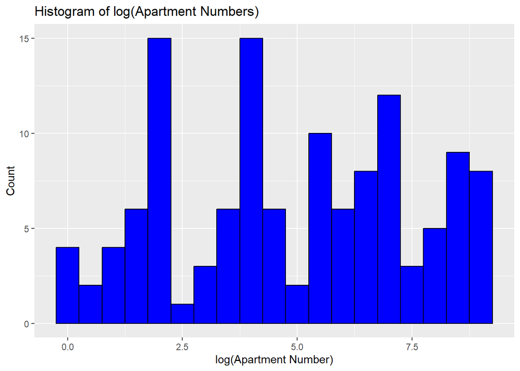

```r
library(ggplot2)
apt_num <- as.numeric(str_extract(aus_data$address, "(?<=#)\\d+"))
ggplot(data.frame(apt_num), aes(x=log(apt_num))) +
  geom_histogram(binwidth = 0.5, fill="blue", color="black") +
  labs(title="Histogram of log(Apartment Numbers)", x="log(Apartment Number)", y="Count")
```

#### f.

```r
leading_digit <- as.numeric(substr(apt_num, 1, 1))
benford_table <- table(leading_digit)/length(leading_digit)
benford_expected <- log10(1 + 1/1:9)

data.frame(Digit = 1:9, Observed = benford_table, Expected = benford_expected)
```

```
  Digit Observed.leading_digit Observed.Freq   Expected
1     1                      1         0.024 0.30103000
2     2                      2         0.036 0.17609126
3     3                      3         0.028 0.12493874
4     4                      4         0.026 0.09691001
5     5                      5         0.028 0.07918125
6     6                      6         0.036 0.06694679
7     7                      7         0.016 0.05799195
8     8                      8         0.022 0.05115252
9     9                      9         0.034 0.04575749
```

#### Resources Used

Tidyverse documentation for str_detect(), other stringr functions, and assistance with Problem 2, R documentation for glm() function, ChatGPT for debugging and explanation of implementation of Benford’s Law.